# Different Techniches to Analyze Credit Balance

How good can we predict Credit balance?

What is the best way to check it?

In order to race our models, we will use the Credit data from ILSR package.

About this data:

*[RDocumentation](https://www.rdocumentation.org/packages/ISLR/versions/1.2/topics/Credit)

# prologue

## set Data

first, let’s set the Environment

libraries:

```r
library(easypackages)

#collect data:
library(ISLR)
attach(Credit)
#random Forest
library(randomForest)
#other models
library(glmnet)
library(Rcmdr)
library(MASS)
#neural network
libraries('tensorflow','keras')
```

```
All packages loaded successfully
```

```r
#install_tensorflow() #install_keras() #install_minicomda
#data tools:
libraries('dplyr','tidyr')
```

```
All packages loaded successfully
```

```r
libraries('Matrix','scales')
```

```
All packages loaded successfully
```

```r
#visual
libraries('ggplot2', 'hrbrthemes','viridis')
```

```
All packages loaded successfully
```

```r
libraries('knitr','kableExtra','sjPlot')
```

```
All packages loaded successfully
```

Now we will see the data’s structure

6 top rows of our table:

```r
head(Credit[,-1],6) %>%
  kbl() %>%
  kable_material(c("striped", "hover"))
```

[output not shown]

before we start to analyze, here a histogram of he credit balance:

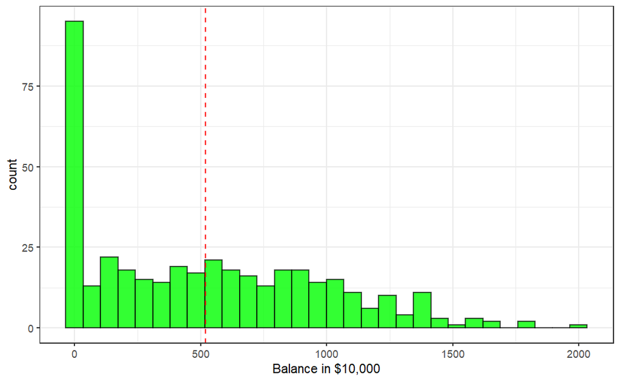

```r
Credit %>%
  ggplot(aes(x=Balance))+
  geom_histogram(color= alpha("black", 0.7),fill= alpha("green", 0.8) )+
  geom_vline(xintercept= mean(Balance), color= "red",lty= "dashed")+
  theme_bw()+labs( x= "Balance in $10,000")
```

what about race, does this factor alone predict the result? and age?

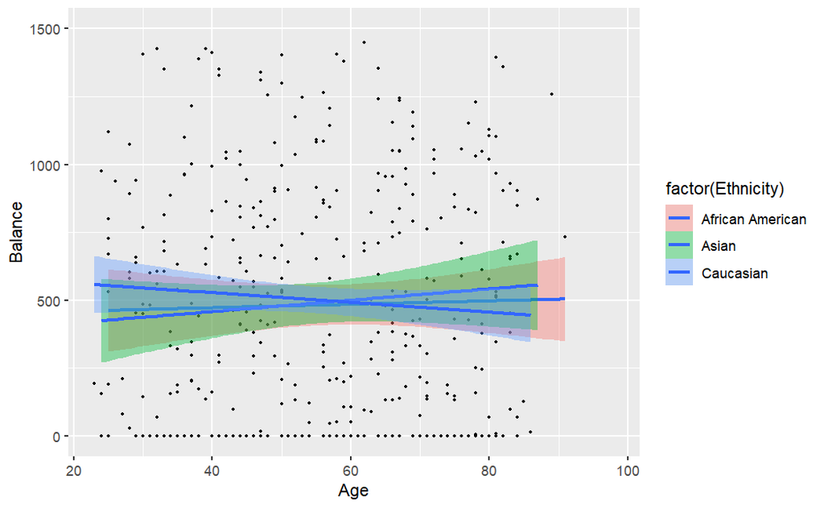

```r
Credit %>%
  ggplot(aes(y=Balance, x=Age,fill= factor(Ethnicity) ))+
  geom_point(size= 0.7)+
  geom_smooth(method = "glm", level= 0.9)+ylim(min(Balance), max(1500))
```

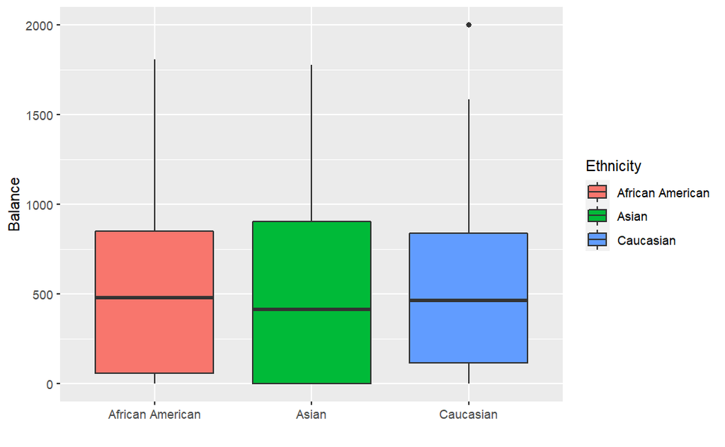

```r
Credit %>%
  ggplot(aes(y=Balance, x=Ethnicity,fill= Ethnicity))+
  geom_boxplot(size= 0.7)+labs(x = "")
```

and what if we will predict by race & gender?

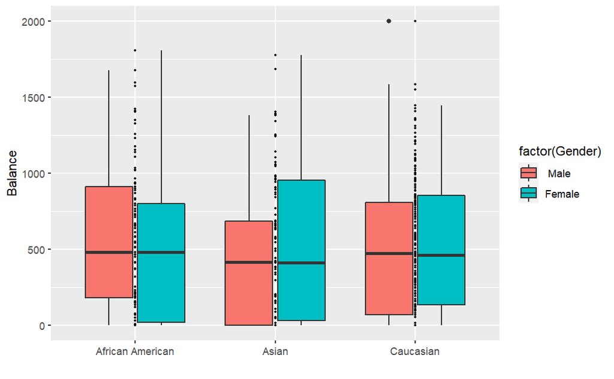

```r
Credit %>%
  ggplot(aes(y=Balance,x= factor(Ethnicity),fill=factor(Gender) ))+
  geom_point(size= 0.7)+
  geom_boxplot(size= 0.7)+
  labs(x= "")
```

Again, there is no clear effect.

One can ask, can all of the weak predictors create a good one together?

So let’s start!

We will ad some variables.

1. High_deg= $T$ if got more than 12 years of education
2. Age_2= $Age^2$ in order to allaw parabolic age effect
3. Bride= interaction of gender ans marriage

also, we will set seed and sample train & test.

```r
Credit <- na.omit(Credit)
n <- nrow(Credit)
set.seed (13)
ntest <- trunc(n / 3)
testid <- sample (1:n, ntest)

Credit<- Credit[,-1] %>%
  mutate(High_deg= Education>=13)%>%
  mutate(Age_2= Age^2)%>%
  mutate(Bride= (Gender== 'Female')&(Married== 'Yes'))
```

Finaly, we can predict with our models

# Models

## Linear

### LM

assumption

$(Y|X) \sim N(BX,\sigma^2)$

```r
lmfit <- lm(Balance ~ ., data = Credit[-testid , ])
lmpred <- predict(lmfit , Credit[testid , ])
err_lm<- abs(Credit$Balance[testid] - lmpred)
mean(err_lm)
```

```
[1] 376.7141
```

Now, what is our best predictors, if we filter our variables and prevent over fitting?

### step wise method

Adding each time variable acording to AIC method.

```r
null_model <- lm(Balance ~1, data =  Credit[-testid , ])
# Stepwise regression model
step_fit <- stepAIC (null_model,k= 2, direction = "forward",scope = list(lower= formula(null_model),upper= formula(lmfit) ) )
step_pred <- predict(step_fit , Credit[testid , ])
err_step<- abs(Credit$Balance[testid] - step_pred)
mean(abs(err_step))
```

[output not shown]

lets see the regression vs the step wise. it is clear that the AIC method choose only the variables with P-value < 5 %

```r
tab_model(lmfit,step_fit, show.ci= F,show.se = T,show.loglik= T)
```

[output not shown]

### lasso

*(use vectors)

assumption

$(Y|X) \sim N(BX,\sigma^2)$, like LM.

but this time we use shrinkage method in order to reduce variance & over fitting. so our minimizing function define as

$RSS+ \lambda {\Sigma}_{j=1}^p |\beta_j|$

when $p=length( \beta)$ and $\lambda$ is a hyper parameter.

```r
x <- scale(model.matrix(Balance ~ . - 1, data = Credit))
y <- Credit$Balance

#glmnet
cvfit <- cv.glmnet(x[-testid , ], y[-testid],
                     type.measure = "mae")
```

this time, we need to set our hipper parameter, $\lambda$ that lead to the minimum mean cross-validated error*

[*see also](https://cran.r-project.org/web/packages/glmnet/vignettes/glmnet.pdf)

```r
lambda.min<- cvfit$lambda.min
cpred <- predict(cvfit, x[testid , ], s = "lambda.min")
err_cp<- abs(y[testid] - cpred)
mean(abs(err_cp))
```

```
[1] 377.0285
```

## Trees

The main algorithm in randomforest, adaboost, etc is splitting the data each time into two samples, in the most effective way by reevaluating the error function.

Mathematicaly, the tree assume a model of form

while $M$ is the numbers of groups, R_m is the specific group & $c_m$ is the parameter of the model.

for a small tree,This is a very weak learner, but it can be used to create deeper learning. too big tree can lead to over-feeting.

### Random Forest

A mean of n-tree

```r
rf_s<- randomForest(formula= Balance ~ ., data = Credit[-testid , ],
                    ntree= 1500, mtry= 6, na.action = na.omit )

pred_s<- predict(rf_s,newdata = Credit[-testid , ] )
rf_pred <- predict(rf_s , Credit[testid , ], s = "lambda.min")
err_rf<- abs(y[testid] - rf_pred)
mean(abs(err_rf))
```

```
[1] 406.3159
```

### Adaboost

```r
norm_y<- 2*y/(max(y)+min(y))-1

adb_s<-randomForest(formula= Balance ~ ., data = Credit[-testid , ],
                    ntree= 1500, mtry= 14, na.action = na.omit, importance= T )

pred_abs <- predict(adb_s , Credit[testid , ], s = "lambda.min")
pred_abs<- head(as.vector(pred_abs),133)
err_adb<- abs(y[testid] - pred_abs)
mean(abs(err_adb))
```

```
[1] 409.2853
```

## Neural Network

Creating of network of nonlinear function and weights, that evaluate the prediction.

this method is the hardest to present due to the coplexativity of the net.

### set seed

```r
modnn <- keras_model_sequential () %>%
  layer_dense(units = 50, activation = "relu",
              input_shape = ncol(x)) %>%
  layer_dropout(rate = 0.4) %>%
  layer_dense(units = 20, activation = 'relu') %>%
  #layer_dropout(rate = 0.3) %>%
  layer_dense(units = 1)

modnn %>% compile(loss = "mse",
                  optimizer = optimizer_rmsprop (),
                  metrics = list("mean_absolute_error")
                  )
modnn
```

[output not shown]

Using the net:

```r
mod_Credit <- modnn %>% fit(
  x[-testid , ], y[-testid], epochs = 1500, batch_size = 32,
  validation_data = list(x[testid , ], y[testid ])
)
```

### Keras result

```r
#show Keras result
summary(mod_Credit)
```

```
        Length Class  Mode
params  3      -none- list
metrics 4      -none- list
```

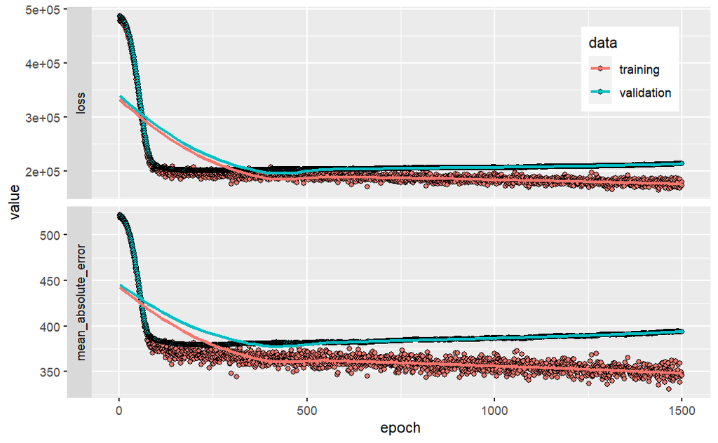

```r
plot(mod_Credit)+theme_gray()+
  theme(plot.caption = element_text(size = 6,hjust= 0),
        legend.position = c(.95, .95),
    legend.justification = c("right", "top"),
    legend.box.just = "right")#,
```

```r
    #legend.margin = margin(6, 6, 6, 6))

nnpred <- predict(modnn , x[testid , ])
err_nn<- abs(y[testid] - nnpred)
mean(abs(err_nn))
```

```
[1] 393.7852
```

## Sum all result

We used the same seed to test all methods, so now we can compare the error of each data.

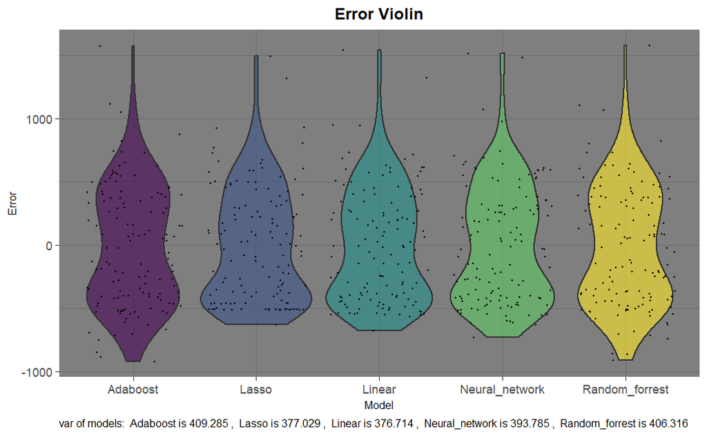

```r
my_pred<- data.frame(c(lmpred,cpred,rf_pred,pred_abs,nnpred)) #pred data frame
m<- length(testid)
modl_nam<-c("Linear", "Lasso", "Random_forrest","Adaboost","Neural_network")
my_pred$Model<- c(rep(modl_nam[1],m),rep(modl_nam[2],m),rep(modl_nam[3],m),
                  rep(modl_nam[4],m),rep(modl_nam[5],m) ) #naming each model in pred data frame
my_pred$Balance<-rep(y[testid],5)
colnames(my_pred)[1]<- "Predict"

my_err<- as.data.frame(cbind(err_lm,err_cp,err_rf,err_adb,err_nn))
my_var<- colMeans(my_err[sapply(my_err, is.numeric)])

#caption- var of the models alphabeticaly
order_script<- order(modl_nam)
script<- paste("var of models: ",modl_nam[order_script[1]], "is", round(my_var[order_script[1]],3))
for (i in order_script[-1]) {
  script<- paste(script, ", ", modl_nam[i], "is", round(my_var[i],3) )}

my_pred %>%
  ggplot( aes(x= Model ,y=Balance-Predict, fill= Model)) +
  geom_violin()+
  scale_fill_viridis(discrete = TRUE, alpha=0.6) +
  geom_jitter(color="black", size=0.45) +
  theme_dark() +
  theme(
    legend.position="none",
    plot.title = element_text(size=12,hjust = 0.5,face = "bold"),
    plot.caption = element_text(size = 8,hjust= 0),
    axis.title = element_text(size = 8))+ ylab("Error")+
  labs(title = "Error Violin",caption = script)
```